# **Personal Information:**

### Balancing the data.

```
Class distribution (counts):
Class 0: 4520
Class 1: 480

Class distribution (percentage):
Class 0: 90.4%
Class 1: 9.6%
```

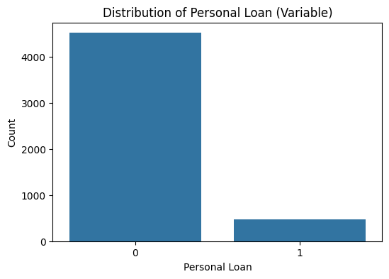

```python
# Count of class distribution
target_count = df['Personal Loan'].value_counts()
print("Class distribution (counts):")
for cls, count in target_count.items():
    print(f"Class {cls}: {count}")

# Percentage distribution
target_percentage = df['Personal Loan'].value_counts(normalize=True) * 100
print("\nClass distribution (percentage):")
for cls, perc in target_percentage.items():
    print(f"Class {cls}: {perc:.1f}%")

# Visualization in bar plot
plt.figure(figsize=(6,4))
sns.countplot(x='Personal Loan', data=df)
plt.title('Distribution of Personal Loan (Variable)')
plt.xlabel('Personal Loan')
plt.ylabel('Count')
plt.show()
```

This is a highly imbalanced dataset, because one class dominating the other (roughly 9:1 ratio).

```
Original training target distribution: Counter({0: 3616, 1: 384})
After SMOTE training target distribution: Counter({0: 3616, 1: 3616})
```

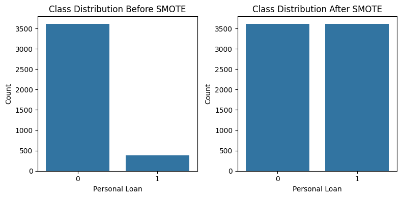

```python
# Balanceing the dataset using SMOTE

# Separating features and target.
# Dropping ID,Personal Loan as it's a categorical column
X = df.drop(['Personal Loan', 'ID'], axis=1, errors='ignore')
y = df['Personal Loan']

# Clean and convert 'CCAvg' to numeric and update the original df
# Split the string by '/' and take the first part of it, then convert it to numeric
df['CCAvg'] = df['CCAvg'].astype(str).str.split('/').str[0]
df['CCAvg'] = pd.to_numeric(df['CCAvg'], errors='coerce')

# Fill any NaNs resulting from the conversion with median
df['CCAvg'] = df['CCAvg'].fillna(df['CCAvg'].median())

# Now update X with the cleaned 'CCAvg' from df
X['CCAvg'] = df['CCAvg']


# Spliting the data (before SMOTE)
X_train, X_test, y_train, y_test = train_test_split(X, y, test_size=0.2, random_state=42, stratify=y)

#smote after scaling.
smote = SMOTE(random_state=42)
X_train_res, y_train_res = smote.fit_resample(X_train, y_train)

# Check new class distribution

counter_before = Counter(y_train)
counter_after = Counter(y_train_res)
print("Original training target distribution:",counter_before)
print("After SMOTE training target distribution:",counter_after)

# Visualization

plt.figure(figsize=(8,4))

# Before SMOTE
plt.subplot(1,2,1)
sns.barplot(x=list(counter_before.keys()), y=list(counter_before.values()))
plt.title("Class Distribution Before SMOTE")
plt.xlabel("Personal Loan")
plt.ylabel("Count")

# After SMOTE
plt.subplot(1,2,2)
sns.barplot(x=list(counter_after.keys()), y=list(counter_after.values()))
plt.title("Class Distribution After SMOTE")
plt.xlabel("Personal Loan")
plt.ylabel("Count")

plt.tight_layout()
plt.show()
```

Exploratory Data Analysis (EDA)

```python
# Summary for categorical features
print("\n Categorical Features Summary ")
print(df[['Education','Family','Online','Securities Account','CD Account','CreditCard']].describe())
```

```
 Categorical Features Summary
         Education       Family       Online  Securities Account  CD Account  \
count  5000.000000  5000.000000  5000.000000         5000.000000  5000.00000
mean      1.791600     2.261800     0.635200            0.104400     0.06040
std       0.839232     1.167533     0.481422            0.305809     0.23825
min       1.000000     1.000000     0.000000            0.000000     0.00000
25%       1.000000     1.000000     0.000000            0.000000     0.00000
50%       2.000000     2.000000     1.000000            0.000000     0.00000
75%       3.000000     3.000000     1.000000            0.000000     0.00000
max       3.000000     4.000000     1.000000            1.000000     1.00000

        CreditCard
count  5000.000000
mean      0.294000
std       0.455637
min       0.000000
25%       0.000000
50%       0.000000
75%       1.000000
max       1.000000
```

Visualization of Target Variable : That is personal loan

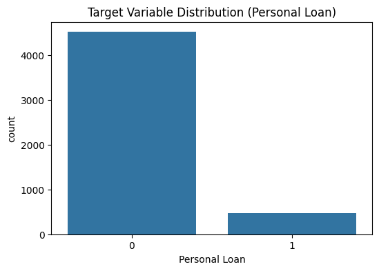

```python
plt.figure(figsize=(6,4))
sns.countplot(x='Personal Loan', data=df)
plt.title('Target Variable Distribution (Personal Loan)')
plt.show()
```

Distribution of Numerical Features

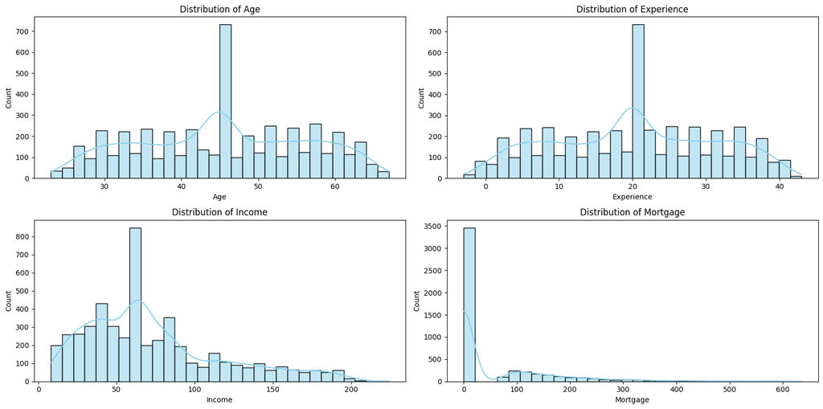

```python
numerical_columns = ['Age', 'Experience', 'Income', 'Mortgage']

plt.figure(figsize=(16,8))
for i, col in enumerate(numerical_columns):
    plt.subplot(2, 2, i+1)
    sns.histplot(df[col], bins=30, kde=True, color='skyblue')
    plt.title(f'Distribution of {col}')
plt.tight_layout()
plt.show()
```

Outlier Detection using IQR (Interquartile Range)

```python
# Columns to check for outliers (numerical)
numerical_columns = ['Age', 'Experience', 'Income', 'Mortgage']

# Using IQR method
print(" Outliers Detection using IQR ")
for col in numerical_columns:
    Q1 = df[col].quantile(0.25)
    Q3 = df[col].quantile(0.75)
    IQR = Q3 - Q1
    lower_bound = Q1 - 1.5 * IQR
    upper_bound = Q3 + 1.5 * IQR

    outlier = df[(df[col] < lower_bound) | (df[col] > upper_bound)]
    print(f"{col}: {len(outlier)} outlier")
```

```
 Outliers Detection using IQR
Age: 0 outlier
Experience: 0 outlier
Income: 228 outlier
Mortgage: 291 outlier
```

Outlier Detection using Z-score

```python
print("\n=== Outliers Detection using Z-score ===")
for col in numerical_cols:
    z_scores = zscore(df[col])
    outliers = df[(z_scores < -3) | (z_scores > 3)]
    print(f"{col}: {len(outliers)} outliers")
```

```
=== Outliers Detection using Z-score ===
Age: 0 outliers
Experience: 0 outliers
Income: 3 outliers
```

### Visualization of numerical columns using Boxplot:

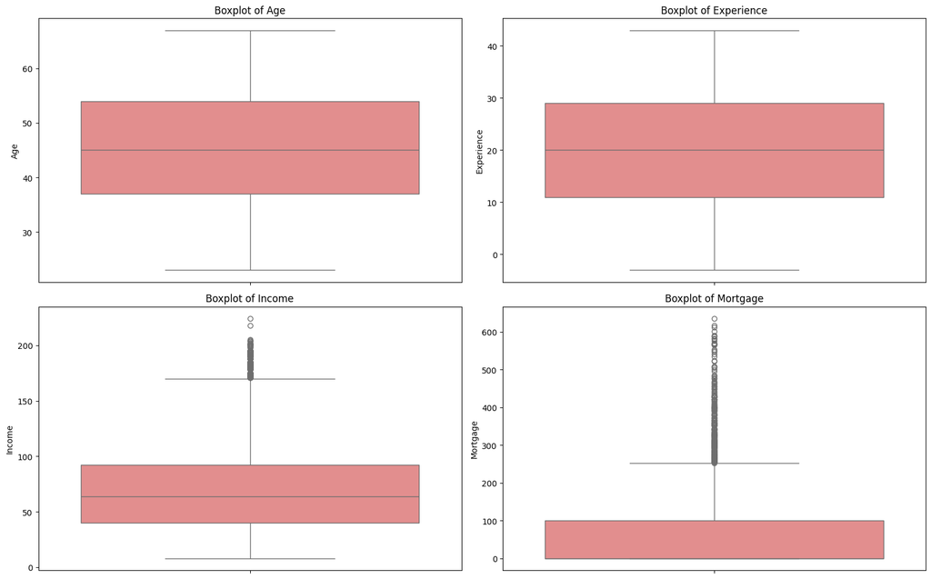

```python
plt.figure(figsize=(16,10))
for i, col in enumerate(numerical_columns):
    plt.subplot(2,2,i+1)
    sns.boxplot(y=df[col],color='lightcoral')
    plt.title(f'Boxplot of {col}')
plt.tight_layout()
plt.show()
```

Relationships Between Features and Target

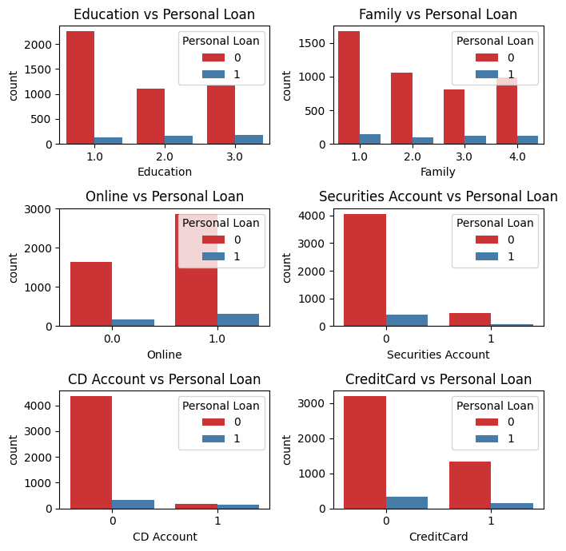

```python
categorical_columns = ['Education','Family','Online','Securities Account','CD Account','CreditCard']

plt.figure(figsize=(7,7))
for i, col in enumerate(categorical_columns):
    plt.subplot(3, 2, i+1)
    sns.countplot(x=col, hue='Personal Loan', data=df, palette='Set1')
    plt.title(f'{col} vs Personal Loan')
plt.tight_layout()
plt.show()
```

Numerical vs Target

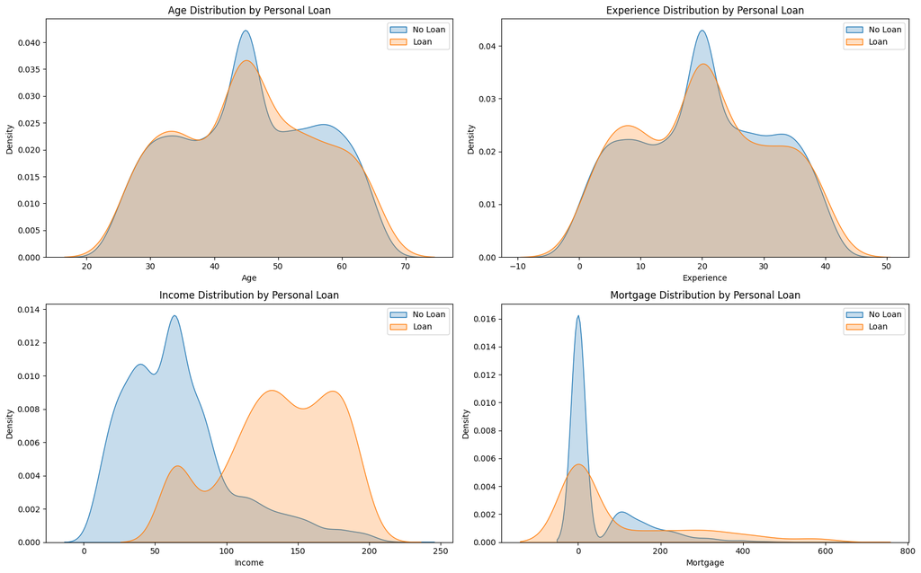

```python
plt.figure(figsize=(16,10))
for i, col in enumerate(numerical_columns):
    plt.subplot(2, 2, i+1)
    sns.kdeplot(data=df[df['Personal Loan']==0], x=col, label='No Loan', fill=True)
    sns.kdeplot(data=df[df['Personal Loan']==1], x=col, label='Loan', fill=True)
    plt.title(f'{col} Distribution by Personal Loan')
    plt.legend()
plt.tight_layout()
plt.show()
```

Correlation Heatmap Visualization:

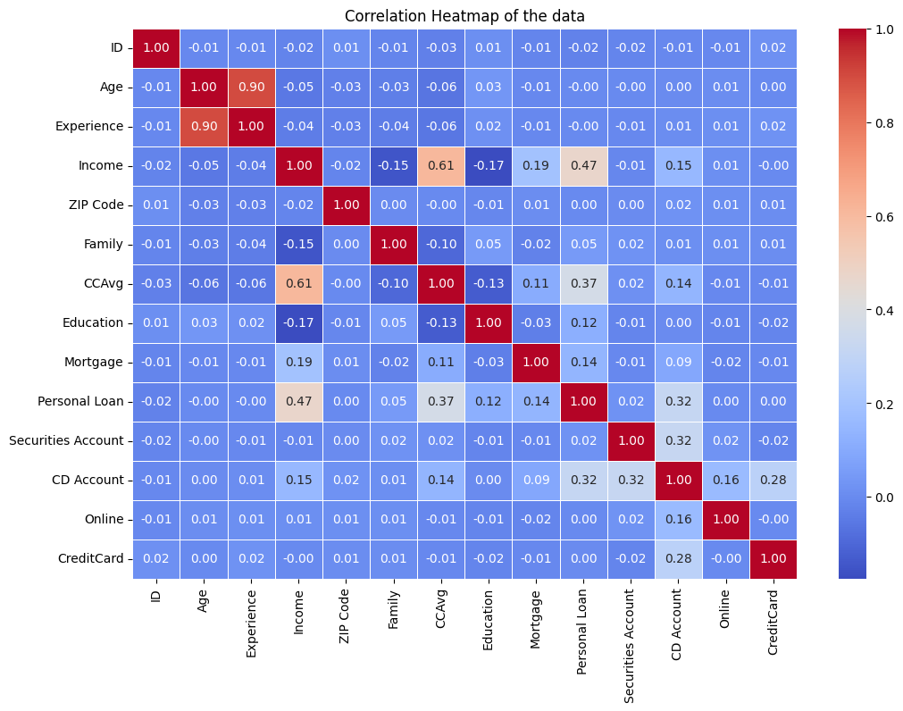

```python
plt.figure(figsize=(12,8))
sns.heatmap(df.corr(), annot=True, fmt=".2f", cmap='coolwarm', linewidths=0.5)
plt.title('Correlation Heatmap of the data')
plt.show()
```

Feature Scaling

```python
numerical_cols = ['Age', 'Experience', 'Income', 'Mortgage']

#StandardScaler (mean=0, std=1)

scaler = StandardScaler()

X_train[numerical_cols] = scaler.fit_transform(X_train[numerical_cols])
X_test[numerical_cols] = scaler.transform(X_test[numerical_cols])

##print("First 5 rows after StandardScaler:")
print(X_train[numerical_cols].head())
```

```
           Age  Experience    Income  Mortgage
408   1.336420    1.438636  0.377634 -0.553909
3737 -0.132728   -0.113685 -0.966097 -0.553909
3889 -1.785520   -0.022372 -1.216623  0.643609
568  -1.050946   -0.022372 -0.715571  1.039483
1041  0.969133    1.073384 -0.487820 -0.553909
```

About Training and Testing data:-

1. Split data into two i.e training and testing sets before modeling.
2. Usually 70-80% for training, 20-30% for testing will be taken.
3. Use stratify on target for imbalanced datasets (though we already balanced with SMOTE).

```python
# Define features (X) and target (y)
X = df.drop(['Personal Loan', 'ID'], axis=1, errors='ignore')  # Features
y = df['Personal Loan']  # Target

# Split into 80% train and 20% test
X_train, X_test, y_train, y_test = train_test_split( X, y, test_size=0.2, random_state=42, stratify=y )

# Checking size of the data
print(f"Size of the Training dataset: {X_train.shape[0]} samples")
print(f"size of the Testing dataset: {X_test.shape[0]} samples")
```

```
Size of the Training dataset: 4000 samples
size of the Testing dataset: 1000 samples
```

Feature Engineering

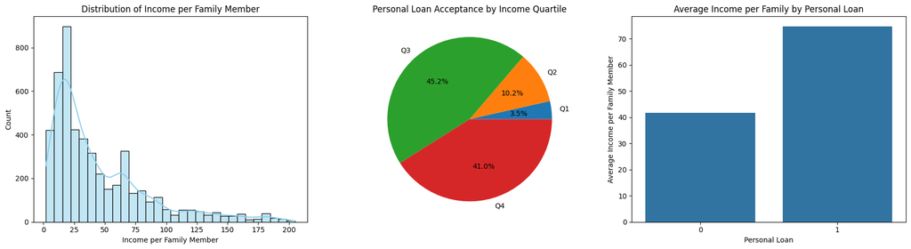

```python
if 'Income_per_Family' not in df.columns:
    df['Income_per_Family'] = df['Income'] / df['Family'].replace(0, np.nan)
    df['Income_per_Family'] = df['Income_per_Family'].fillna(df['Income_per_Family'].median()) # Fill the resulting NaNs values with median

#Create quartiles for Income_per_Family
df['Income_quartile'] = pd.qcut(df['Income_per_Family'], 4, labels=['Q1','Q2','Q3','Q4'])

#Loan counts by income quartile
loan_counts = df[df['Personal Loan']==1]['Income_quartile'].value_counts().sort_index()

#Average income per family by loan
avg_income = df.groupby('Personal Loan')['Income_per_Family'].mean()


#Create Dashboard with 3 plots
plt.figure(figsize=(18,5))

#1) Histogram
plt.subplot(1,3,1)
sns.histplot(df['Income_per_Family'], bins=30, kde=True, color='skyblue')
plt.title('Distribution of Income per Family Member')
plt.xlabel('Income per Family Member')
plt.ylabel('Count')

#2) Pie Chart
plt.subplot(1,3,2)
plt.pie(loan_counts, labels=loan_counts.index, autopct='%1.1f%%',)
plt.title('Personal Loan Acceptance by Income Quartile')

#3) Bar Chart
plt.subplot(1,3,3)
sns.barplot(x=avg_income.index, y=avg_income.values)
plt.title('Average Income per Family by Personal Loan')
plt.xlabel('Personal Loan')
plt.ylabel('Average Income per Family Member')

plt.tight_layout()
plt.show()
```

```python
# Inverse transform the scaled 'Income' back to original scale
df['Original_Income'] = scaler.inverse_transform(X[numerical_cols])[:, X.columns.get_loc('Income')]

# Create 'Income_per_Family' feature, handling division by zero
df['Income_per_Family'] = df['Original_Income'] / df['Family'].replace(0, np.nan) # Replace 0's with NaN to avoid division by zero
df['Income_per_Family'] = df['Income_per_Family'].fillna(df['Income_per_Family'].median()) # Fill the resulting NaNs values with median

# Dropping the temporary 'Original_Income' column
df.drop(columns=['Original_Income'], inplace=True)

display(df[['Income', 'Family', 'Income_per_Family']].head())
```

|  | Income | Family | Income_per_Family |
| --- | --- | --- | --- |
| 0 | 49.0 | 4.0 | 555.973004 |
| 1 | 34.0 | 3.0 | 521.759275 |
| 2 | 11.0 | 1.0 | 555.402738 |
| 3 | 64.0 | 1.0 | 2882.506203 |
| 4 | 45.0 | 1.0 | 2048.261564 |

# Model Training:

## 1. Logistic Regression:

```
181/181 ━━━━━━━━━━━━━━━━━━━━ 2s 4ms/step - accuracy: 0.7134 - loss: 0.5867 - val_accuracy: 0.7512 - val_loss: 0.4642
181/181 ━━━━━━━━━━━━━━━━━━━━ 1s 3ms/step - accuracy: 0.8412 - loss: 0.3584 - val_accuracy: 0.8176 - val_loss: 0.3755
181/181 ━━━━━━━━━━━━━━━━━━━━ 1s 3ms/step - accuracy: 0.8954 - loss: 0.2701 - val_accuracy: 0.8701 - val_loss: 0.3104
181/181 ━━━━━━━━━━━━━━━━━━━━ 1s 3ms/step - accuracy: 0.9029 - loss: 0.2390 - val_accuracy: 0.8701 - val_loss: 0.2995
181/181 ━━━━━━━━━━━━━━━━━━━━ 1s 3ms/step - accuracy: 0.9054 - loss: 0.2284 - val_accuracy: 0.8749 - val_loss: 0.2837
181/181 ━━━━━━━━━━━━━━━━━━━━ 1s 3ms/step - accuracy: 0.9154 - loss: 0.2112 - val_accuracy: 0.8625 - val_loss: 0.3040
181/181 ━━━━━━━━━━━━━━━━━━━━ 1s 4ms/step - accuracy: 0.9209 - loss: 0.1910 - val_accuracy: 0.8908 - val_loss: 0.2658
181/181 ━━━━━━━━━━━━━━━━━━━━ 1s 5ms/step - accuracy: 0.9195 - loss: 0.2037 - val_accuracy: 0.8956 - val_loss: 0.2643
181/181 ━━━━━━━━━━━━━━━━━━━━ 1s 3ms/step - accuracy: 0.9245 - loss: 0.1823 - val_accuracy: 0.9060 - val_loss: 0.2465
181/181 ━━━━━━━━━━━━━━━━━━━━ 1s 3ms/step - accuracy: 0.9295 - loss: 0.1788 - val_accuracy: 0.9046 - val_loss: 0.2532
181/181 ━━━━━━━━━━━━━━━━━━━━ 1s 3ms/step - accuracy: 0.9298 - loss: 0.1741 - val_accuracy: 0.9053 - val_loss: 0.2529
181/181 ━━━━━━━━━━━━━━━━━━━━ 1s 3ms/step - accuracy: 0.9322 - loss: 0.1664 - val_accuracy: 0.9060 - val_loss: 0.2520
181/181 ━━━━━━━━━━━━━━━━━━━━ 1s 3ms/step - accuracy: 0.9263 - loss: 0.1800 - val_accuracy: 0.9157 - val_loss: 0.2342
181/181 ━━━━━━━━━━━━━━━━━━━━ 1s 3ms/step - accuracy: 0.9324 - loss: 0.1689 - val_accuracy: 0.9088 - val_loss: 0.2423
181/181 ━━━━━━━━━━━━━━━━━━━━ 1s 3ms/step - accuracy: 0.9434 - loss: 0.1487 - val_accuracy: 0.9150 - val_loss: 0.2325
181/181 ━━━━━━━━━━━━━━━━━━━━ 1s 3ms/step - accuracy: 0.9343 - loss: 0.1645 - val_accuracy: 0.9205 - val_loss: 0.2238
181/181 ━━━━━━━━━━━━━━━━━━━━ 1s 3ms/step - accuracy: 0.9361 - loss: 0.1594 - val_accuracy: 0.9205 - val_loss: 0.2178
181/181 ━━━━━━━━━━━━━━━━━━━━ 1s 3ms/step - accuracy: 0.9365 - loss: 0.1586 - val_accuracy: 0.9205 - val_loss: 0.2171
181/181 ━━━━━━━━━━━━━━━━━━━━ 1s 3ms/step - accuracy: 0.9393 - loss: 0.1638 - val_accuracy: 0.9157 - val_loss: 0.2262
181/181 ━━━━━━━━━━━━━━━━━━━━ 1s 3ms/step - accuracy: 0.9443 - loss: 0.1372 - val_accuracy: 0.9233 - val_loss: 0.2164
181/181 ━━━━━━━━━━━━━━━━━━━━ 1s 3ms/step - accuracy: 0.9476 - loss: 0.1434 - val_accuracy: 0.9233 - val_loss: 0.2091
181/181 ━━━━━━━━━━━━━━━━━━━━ 1s 3ms/step - accuracy: 0.9416 - loss: 0.1492 - val_accuracy: 0.9226 - val_loss: 0.2124
181/181 ━━━━━━━━━━━━━━━━━━━━ 1s 3ms/step - accuracy: 0.9405 - loss: 0.1498 - val_accuracy: 0.9240 - val_loss: 0.2047
181/181 ━━━━━━━━━━━━━━━━━━━━ 1s 3ms/step - accuracy: 0.9355 - loss: 0.1554 - val_accuracy: 0.9212 - val_loss: 0.2116
181/181 ━━━━━━━━━━━━━━━━━━━━ 1s 3ms/step - accuracy: 0.9470 - loss: 0.1436 - val_accuracy: 0.9254 - val_loss: 0.2039
181/181 ━━━━━━━━━━━━━━━━━━━━ 1s 3ms/step - accuracy: 0.9454 - loss: 0.1421 - val_accuracy: 0.9198 - val_loss: 0.2138
181/181 ━━━━━━━━━━━━━━━━━━━━ 1s 5ms/step - accuracy: 0.9447 - loss: 0.1399 - val_accuracy: 0.9233 - val_loss: 0.2062
181/181 ━━━━━━━━━━━━━━━━━━━━ 1s 5ms/step - accuracy: 0.9449 - loss: 0.1385 - val_accuracy: 0.9261 - val_loss: 0.1999
181/181 ━━━━━━━━━━━━━━━━━━━━ 1s 3ms/step - accuracy: 0.9464 - loss: 0.1387 - val_accuracy: 0.9330 - val_loss: 0.1882
181/181 ━━━━━━━━━━━━━━━━━━━━ 1s 3ms/step - accuracy: 0.9421 - loss: 0.1438 - val_accuracy: 0.9288 - val_loss: 0.1921
181/181 ━━━━━━━━━━━━━━━━━━━━ 1s 3ms/step - accuracy: 0.9493 - loss: 0.1357 - val_accuracy: 0.9281 - val_loss: 0.1919
181/181 ━━━━━━━━━━━━━━━━━━━━ 1s 3ms/step - accuracy: 0.9518 - loss: 0.1331 - val_accuracy: 0.9281 - val_loss: 0.1952
181/181 ━━━━━━━━━━━━━━━━━━━━ 1s 3ms/step - accuracy: 0.9484 - loss: 0.1316 - val_accuracy: 0.9254 - val_loss: 0.1964
181/181 ━━━━━━━━━━━━━━━━━━━━ 1s 3ms/step - accuracy: 0.9448 - loss: 0.1414 - val_accuracy: 0.9274 - val_loss: 0.1964
32/32 ━━━━━━━━━━━━━━━━━━━━ 0s 3ms/step
Best threshold for F1: 0.85, F1-score: 0.7978

 Logistic Regression Model Evaluation:
Accuracy : 0.9640
Precision: 0.8659
Recall  : 0.7396
F1-score: 0.7978
```

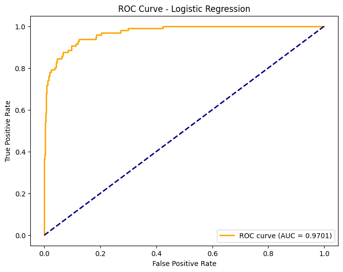

```python
#Preprocessing of the data

#features and target
X = df.drop(['Personal Loan', 'Income_quartile'], axis=1, errors='ignore')
y = df['Personal Loan']

#Feature scaling
scaler = StandardScaler()
X_scaled = scaler.fit_transform(X)

#Train-test split data
X_train, X_test, y_train, y_test = train_test_split(X_scaled, y, test_size=0.2, random_state=42, stratify=y)

#Balancing training data
smote = SMOTE(random_state=42)
X_train_res, y_train_res = smote.fit_resample(X_train, y_train)

#Compute class weights
class_weights = class_weight.compute_class_weight(class_weight='balanced',
    classes=np.unique(y_train_res),y=y_train_res)
class_weights_dict = dict(enumerate(class_weights))

#Build Neural Network
model = Sequential()
# Optional hidden layer to improve learning
model.add(Dense(16, input_dim=X_train_res.shape[1], activation='relu'))
model.add(Dense(1, activation='sigmoid'))

model.compile(optimizer='adam', loss='binary_crossentropy', metrics=['accuracy'])

#Early stopping to prevent from overfitting
early_stop = EarlyStopping(monitor='val_loss', patience=5, restore_best_weights=True)

#Train model
history = model.fit(
    X_train_res, y_train_res,
    epochs=50,batch_size=32,
    validation_split=0.2,
    verbose=1,callbacks=[early_stop],
    class_weight=class_weights_dict
)

#Make predictions
y_pred_prob = model.predict(X_test).flatten()

#Automatically finding best threshold to maximize F1
thresholds = np.arange(0.1, 0.9, 0.01)
f1_scores = []
for t in thresholds:
    y_pred_temp = (y_pred_prob > t).astype(int)
    f1_scores.append(f1_score(y_test, y_pred_temp))

best_idx = np.argmax(f1_scores)
best_threshold = thresholds[best_idx]
print(f"Best threshold for F1: {best_threshold:.2f}, F1-score: {f1_scores[best_idx]:.4f}")

#Applying best threshold
y_pred = (y_pred_prob > best_threshold).astype(int)

#Evaluation of the model
accuracy = accuracy_score(y_test, y_pred)
precision = precision_score(y_test, y_pred)
recall = recall_score(y_test, y_pred)
f1 = f1_score(y_test, y_pred)

print("\n Logistic Regression Model Evaluation: ")
print(f"Accuracy : {accuracy:.4f}")
print(f"Precision: {precision:.4f}")
print(f"Recall  : {recall:.4f}")
print(f"F1-score: {f1:.4f}")

#Visualization of ROC(AUC) curve
fpr, tpr, thresholds_roc = roc_curve(y_test, y_pred_prob)
roc_auc = auc(fpr, tpr)

plt.figure(figsize=(8,6))
plt.plot(fpr, tpr, color='orange', lw=2, label=f'ROC curve (AUC = {roc_auc:.4f})')
plt.plot([0, 1], [0, 1], color='navy', lw=2, linestyle='--')
plt.xlabel('False Positive Rate')
plt.ylabel('True Positive Rate')
plt.title('ROC Curve - Logistic Regression')
plt.legend(loc="lower right")
plt.show()
```

## 2. Logistic Regression using Pytorch :

```
Best threshold for F1: 0.79, F1-score: 0.8042

 Enhanced PyTorch Logistic Regression Evaluation
Accuracy: 0.9630
Precision: 0.8172
Recall: 0.7917
F1-score: 0.8042
```

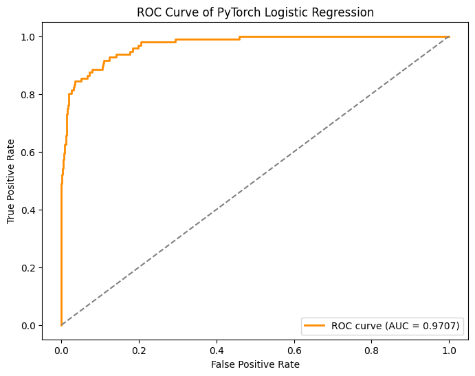

```python
#Preprocessing of the data
X = df.drop(['Personal Loan', 'Income_quartile'], axis=1, errors='ignore')
y = df['Personal Loan']

#Train-test split
X_train,X_test,y_train,y_test = train_test_split(
    X, y, test_size=0.2,random_state=42, stratify=y
)

#Feature scaling
scaler =StandardScaler()
X_train_scaled =scaler.fit_transform(X_train)
X_test_scaled =scaler.transform(X_test)


#Balancing training data
smote =SMOTE(random_state=42)
X_train_res, y_train_res =smote.fit_resample(X_train_scaled, y_train)

#PyTorch tensors and DataLoader
X_train_tensor =torch.tensor(X_train_res, dtype=torch.float32)
y_train_tensor =torch.tensor(y_train_res.values, dtype=torch.float32).view(-1, 1)

train_dataset =TensorDataset(X_train_tensor,y_train_tensor)
train_loader =DataLoader(train_dataset,batch_size=64,shuffle=True)

X_test_tensor =torch.tensor(X_test_scaled,dtype=torch.float32)
y_test_tensor =torch.tensor(y_test.values,dtype=torch.float32).view(-1, 1)

#Compute class weights
weights = class_weight.compute_class_weight(class_weight='balanced', classes=np.unique(y_train_res), y=y_train_res)
weight_tensor = torch.tensor(weights[1] / weights[0], dtype=torch.float32)  # weight for positive class

#Logistic Regression :
class LogisticRegressionModel(nn.Module):
    def __init__(self, input_dim):
        super().__init__()
        # Optional hidden layer for non-linearity
        self.hidden = nn.Linear(input_dim, 16)
        self.output = nn.Linear(16, 1)
        self.relu = nn.ReLU()
        self.sigmoid = nn.Sigmoid()

    def forward(self, x):
        x = self.relu(self.hidden(x))
        x = self.sigmoid(self.output(x))
        return x

model = LogisticRegressionModel(X_train_tensor.shape[1])

#Weighted BCE Loss
criterion = nn.BCELoss()
# Corrected typo from optimzers to optim
optimizer = optim.SGD(model.parameters(), lr=0.005)

#Training with Early Stopping
epochs = 200
best_loss = float('inf')
patience = 10
trigger_times = 0

for epoch in range(epochs):
    model.train()
    epoch_loss = 0
    for batch_X, batch_y in train_loader:
        optimizer.zero_grad()
        outputs = model(batch_X)

        #Apply weight to positive class
        loss = criterion(outputs,batch_y)
        loss.backward()
        optimizer.step()
        epoch_loss += loss.item()
    epoch_loss /= len(train_loader)

    if epoch_loss < best_loss:
        best_loss = epoch_loss
        trigger_times = 0
        best_model_state = model.state_dict()
    else:
        trigger_times += 1
        if trigger_times >= patience:
            print(f"Early stopping at epoch {epoch+1}")
            break

#Loading best weights
model.load_state_dict(best_model_state)

#Evaluation
model.eval()
with torch.no_grad():
    y_pred_prob = model(X_test_tensor).numpy().flatten()

#Find best threshold to maximize F1:
thresholds = np.arange(0.1, 0.9, 0.01)
f1_scores = []
for t in thresholds:
    y_pred_temp = (y_pred_prob > t).astype(int)
    f1_scores.append(f1_score(y_test, y_pred_temp))

best_idx = np.argmax(f1_scores)
best_threshold = thresholds[best_idx]
print(f"Best threshold for F1: {best_threshold:.2f}, F1-score: {f1_scores[best_idx]:.4f}")

y_pred = (y_pred_prob > best_threshold).astype(int)

accuracy =accuracy_score(y_test, y_pred)
precision =precision_score(y_test, y_pred)
recall =recall_score(y_test, y_pred)
f1 = f1_score(y_test, y_pred)

print("\n Enhanced PyTorch Logistic Regression Evaluation ")
print(f"Accuracy: {accuracy:.4f}")
print(f"Precision: {precision:.4f}")
print(f"Recall: {recall:.4f}")
print(f"F1-score: {f1:.4f}")

# Visualization ROC Curve
fpr, tpr, thresholds_roc =roc_curve(y_test, y_pred_prob)
roc_auc = auc(fpr, tpr)

plt.figure(figsize=(8, 6))
plt.plot(fpr, tpr, color='darkorange',lw=2, label=f'ROC curve (AUC = {roc_auc:.4f})')
plt.plot([0, 1],[0, 1], '--', color='gray')
plt.xlabel('False Positive Rate')
plt.ylabel('True Positive Rate')
plt.title('ROC Curve of PyTorch Logistic Regression')
plt.legend(loc='lower right')
plt.show()
```

## 3. Decision Tree Model:

```
Best threshold for F1: 0.10, F1-score: 0.7692

 Decision Tree Model Evaluation
Accuracy: 0.9490
Precision: 0.6800
Recall: 0.8854
F1-score: 0.7692
```

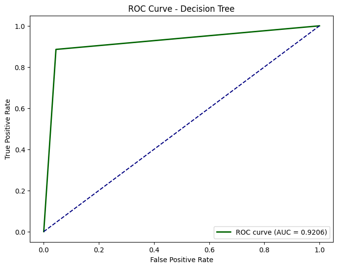

```python
#Preprocessing of the data
X = df.drop(['Personal Loan', 'Income_quartile'], axis=1, errors='ignore')
y = df['Personal Loan']

# Train-test split
X_train,X_test,y_train,y_test = train_test_split(X, y, test_size=0.2, random_state=42, stratify=y)

#Balancing training data using SMOTE
smote = SMOTE(random_state=42)
X_train_res,y_train_res =smote.fit_resample(X_train, y_train)

#Feature scaling
scaler =StandardScaler()
X_train_res =scaler.fit_transform(X_train_res)
X_test_scaled =scaler.transform(X_test)

#Ensure X_test has correct column names
X_test_df =pd.DataFrame(X_test_scaled,columns=X_train.columns)

#Train Decision Tree
dt_model = DecisionTreeClassifier(
random_state=42,max_depth=None,min_samples_split=2,class_weight='balanced')
dt_model.fit(X_train_res, y_train_res)

#Prediction and Threshold Tuning
y_pred_prob = dt_model.predict_proba(X_test_df)[:, 1]

#Automatically finding the best threshold for F1
thresholds = np.arange(0.1, 0.9, 0.01)
f1_scores = []
for t in thresholds:
    y_pred_temp = (y_pred_prob > t).astype(int)
    f1_scores.append(f1_score(y_test, y_pred_temp))

best_idx = np.argmax(f1_scores)
best_threshold = thresholds[best_idx]
print(f"Best threshold for F1: {best_threshold:.2f}, F1-score: {f1_scores[best_idx]:.4f}")

#Applying best threshold
y_pred = (y_pred_prob >best_threshold).astype(int)

#Evaluation
accuracy = accuracy_score(y_test, y_pred)
precision = precision_score(y_test, y_pred, zero_division=0)
recall = recall_score(y_test, y_pred, zero_division=0)
f1 = f1_score(y_test, y_pred, zero_division=0)

print("\n Decision Tree Model Evaluation ")
print(f"Accuracy: {accuracy:.4f}")
print(f"Precision: {precision:.4f}")
print(f"Recall: {recall:.4f}")
print(f"F1-score: {f1:.4f}")

#Visualization of ROC-AUC Curve
fpr, tpr, thresholds_roc = roc_curve(y_test, y_pred_prob)
roc_auc = auc(fpr, tpr)

plt.figure(figsize=(8,6))
plt.plot(fpr, tpr, color='darkgreen',lw=2,label=f'ROC curve (AUC = {roc_auc:.4f})')
plt.plot([0,1],[0,1],'--', color='navy')
plt.xlabel('False Positive Rate')
plt.ylabel('True Positive Rate')
plt.title('ROC Curve - Decision Tree')
plt.legend(loc="lower right")
plt.show()
```

## 4. K-Nearest Neighbors(KNN):

```
 KNN Model Evaluation values
Accuracy: 0.9470
Precision : 0.9216
Recall : 0.4896
F1-score : 0.6395
```

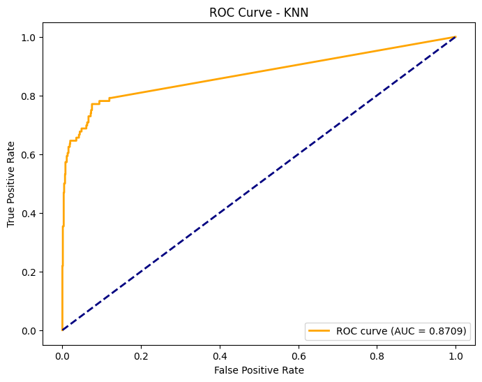

```python
#Preprocessing of data

X = df.drop(['Personal Loan', 'Income_quartile'], axis=1, errors='ignore')  # drop Income_quartile if exists
y = df['Personal Loan'].astype(int)

#scale of the numeric features
numeric_cols =X.select_dtypes(include=['int64', 'float64']).columns
scaler = StandardScaler()
X[numeric_cols] = scaler.fit_transform(X[numeric_cols])

#Train-test data split

X_train,X_test,y_train,y_test =train_test_split(X, y,test_size=0.2,random_state=42,stratify=y)

#Initialization of  KNN
knn_model = KNeighborsClassifier(n_neighbors=5, weights='distance')
knn_model.fit(X_train, y_train)


#Predictions
y_pred = knn_model.predict(X_test)
y_pred_prob = knn_model.predict_proba(X_test)[:, 1]


#Evaluating the model
accuracy =accuracy_score(y_test, y_pred)
precision =precision_score(y_test, y_pred, zero_division=0)
recall =recall_score(y_test, y_pred, zero_division=0)
f1 =f1_score(y_test, y_pred, zero_division=0)

print("\n KNN Model Evaluation values ")
print(f"Accuracy: {accuracy:.4f}")
print(f"Precision : {precision:.4f}")
print(f"Recall : {recall:.4f}")
print(f"F1-score : {f1:.4f}")


#Visualiztion of ROC Curve

fpr, tpr, thresholds = roc_curve(y_test, y_pred_prob)
roc_auc = auc(fpr, tpr)

plt.figure(figsize=(8,6))
plt.plot(fpr, tpr, color='orange', lw=2, label=f'ROC curve (AUC = {roc_auc:.4f})')
plt.plot([0, 1], [0, 1], color='navy', lw=2, linestyle='--')
plt.xlabel('False Positive Rate')
plt.ylabel('True Positive Rate')
plt.title('ROC Curve - KNN')
plt.legend(loc="lower right")
plt.show()
```

## Dashborad for Confusion matrices:

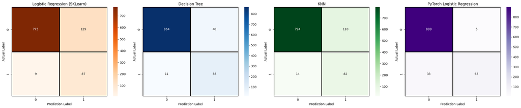

```python
if isinstance(X_train_res, pd.DataFrame) or isinstance(X_train_res, pd.Series):
    X_train_res_np = X_train_res.values
else:
    X_train_res_np = np.array(X_train_res)

if isinstance(y_train_res, pd.DataFrame) or isinstance(y_train_res, pd.Series):
    y_train_res_np = y_train_res.values
else:
    y_train_res_np = np.array(y_train_res)

if isinstance(X_test_scaled, pd.DataFrame) or isinstance(X_test_scaled, pd.Series):
    X_test_np = X_test_scaled.values
else:
    X_test_np = np.array(X_test_scaled)

if isinstance(y_test, pd.DataFrame) or isinstance(y_test, pd.Series):
    y_test_np = y_test.values
else:
    y_test_np = np.array(y_test)


# 1) Logistic Regression (using scikit-learn)

log_model= LogisticRegression(random_state=42, max_iter=1000, class_weight='balanced')
log_model.fit(X_train_res_np, y_train_res_np) # Fit the model
y_pred_log = log_model.predict(X_test_np)
cm_logistic = confusion_matrix(y_test_np, y_pred_log)

# 2) PyTorch Logistic Regression

model.eval()
with torch.no_grad():
    y_pred_prob_pytorch = model(torch.tensor(X_test_np, dtype=torch.float32)).numpy().flatten()

# Use a default threshold of 0.5 for the confusion matrix visualization
y_pred_pytorch = (y_pred_prob_pytorch > 0.5).astype(int)
cm_pytorch = confusion_matrix(y_test_np, y_pred_pytorch)

# 3) Decision Tree

tree_model = DecisionTreeClassifier(random_state=42, class_weight='balanced', max_depth=None, min_samples_split=2)
tree_model.fit(X_train_res_np, y_train_res_np) # Fit the model
y_pred_tree= tree_model.predict(X_test_np)
cm_tree = confusion_matrix(y_test_np, y_pred_tree)

# 4) KNN

knn_model= KNeighborsClassifier(n_neighbors=5)
knn_model.fit(X_train_res_np, y_train_res_np) # Fit the model
y_pred_knn =knn_model.predict(X_test_np)
cm_knn = confusion_matrix(y_test_np, y_pred_knn)


#Combining all the confusion matrices
cms = [cm_logistic, cm_tree, cm_knn, cm_pytorch]
model_names = ["Logistic Regression (SKLearn)", "Decision Tree", "KNN", "PyTorch Logistic Regression"] # Updated name
cmaps = ["Oranges", "Blues", "Greens", "Purples"]

#Ploting dashboard
fig, axes = plt.subplots(1, 4, figsize=(24,5))

for i, ax in enumerate(axes):
    sns.heatmap(cms[i], annot=True, fmt='d', cmap=cmaps[i],cbar=True, linewidths=1, linecolor='black', ax=ax)
    ax.set_xlabel("Prediction Label")
    ax.set_ylabel("Actual Label")
    ax.set_title(f"{model_names[i]}")

plt.tight_layout()
plt.show()
```